# Modeling The Kenai River Dip Net Fishery

Charles Hans Thompson

Tuesday, March 03, 2015

I would like to develop a model to predict the catchable sockeye at the mouth of the kenai River. I’m trying to do this currently using three data sources.

- Cook Inlet Test Fish data going back to 1979
- The personal use harvest survey data that is available to me going back to 2006.
- The sonar count data on the Kenai river 19 miles up river going back to 1979.

I’ve configured this data from excel spreadsheets into tidy R data frames and made them available with the analysis.R file for producing the graphics here on github, a code repository website. The code is at https://github.com/hansthompson/kenai_dip_net.

I’m trying to model this data because I am enamored with the personal use fishery at the mouth of the Kenai river. It brings in families from the diversity cultures and classes of people from south central Alaska, provides ample salmon for the year to those that don’t have the time or training to go sport fishing, and allows many Alaskans to have a buy in for the cause of sustainable management of salmon. I’ve been going the past three years and it is a striking site of humanity.

I’ll now try break down the data for you. I don’t really have a good plan to move beyond where I am now.

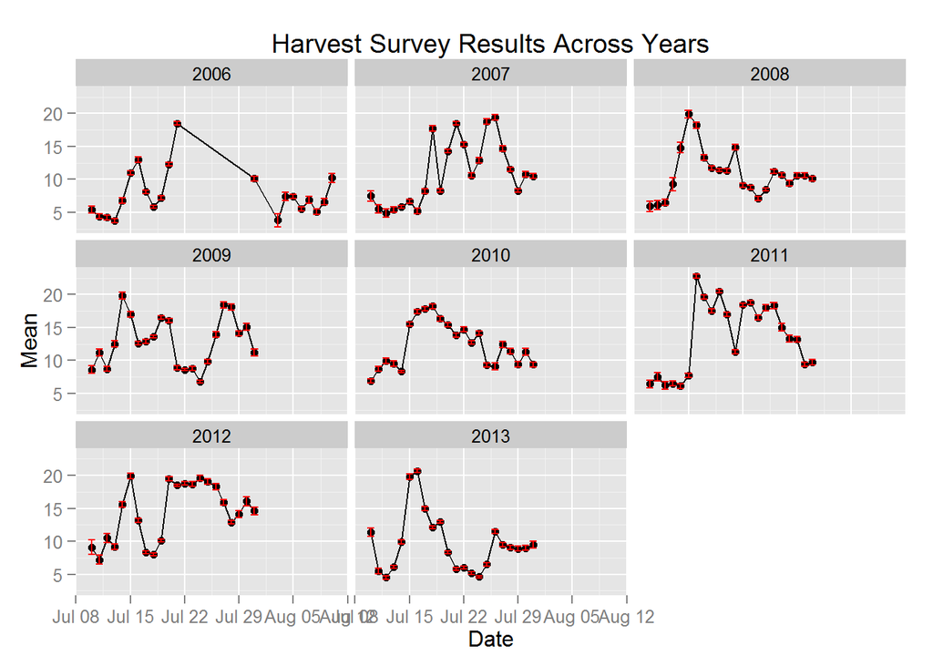

These are the harvest survey results from 2006-2013. The y axis is the estimated mean catch for the day for personal use dip net fishers with standard error bars. This data was provided to me from a personal request on the fishery. There is a big hole in 2006 but I’ve included it for formality.

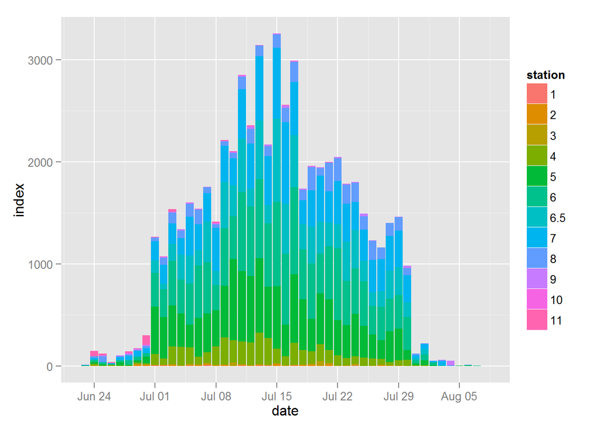

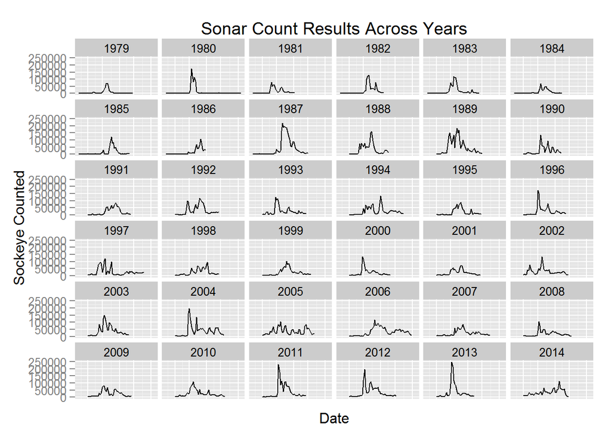

These are the distributions of prior year sonar returns at the 19 mile upriver sonar station. The start and end dates for the season are different across years but the season runs from early July to the middle of August.

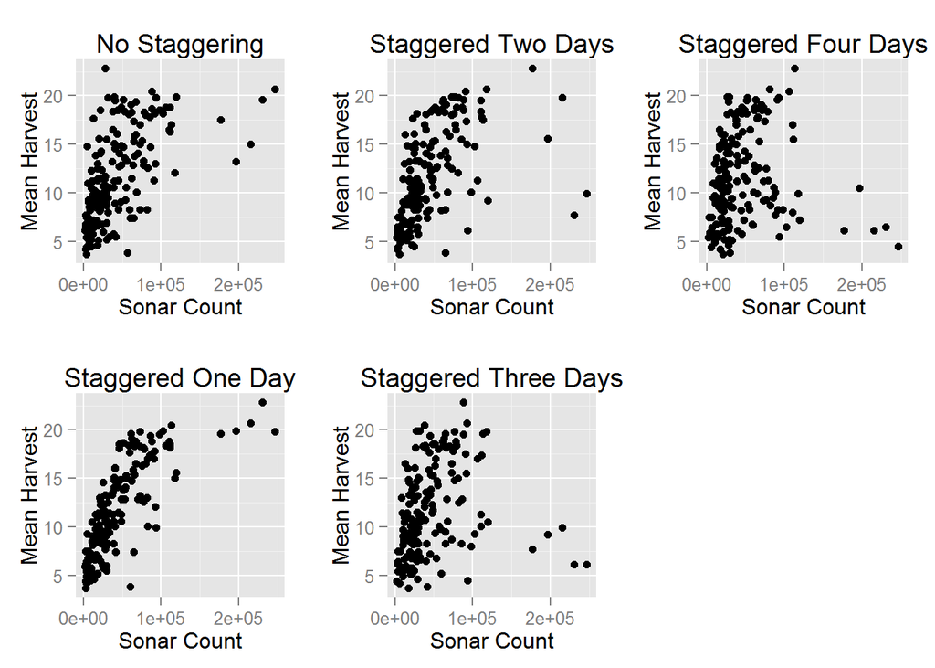

I’ve tried to how long it takes for the sockeye to reach the sonar station from the mouth of the river by plotting the mean catch at the river mouth by the day with the sonar count by the day and staggering by each day. It looks like by staggering the mean catch at the mouth by one day provides the best correlation to sonar count. In the next graphic I look at the negative log of the p-value for linear and log models for each of the staggering options.

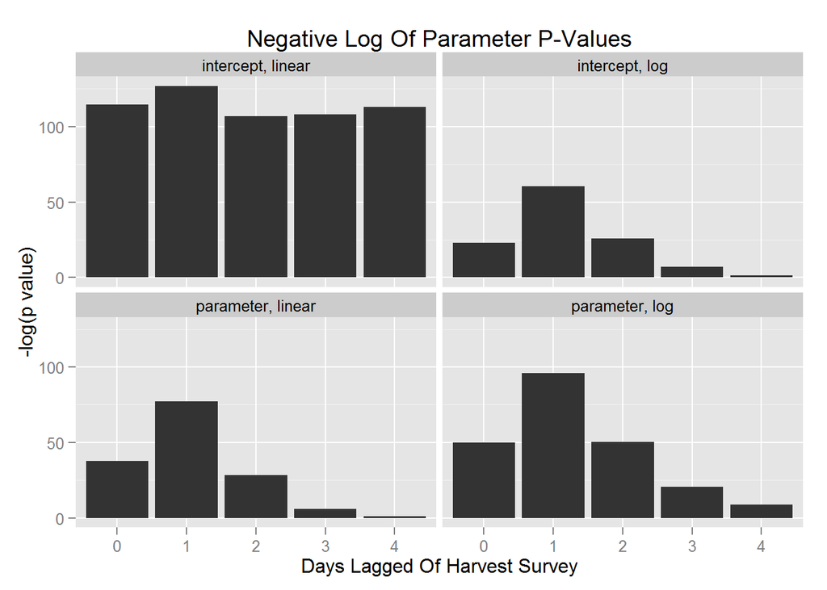

It looks like the log based regression where there is one day of staggering has the best fit.

[figure not shown]

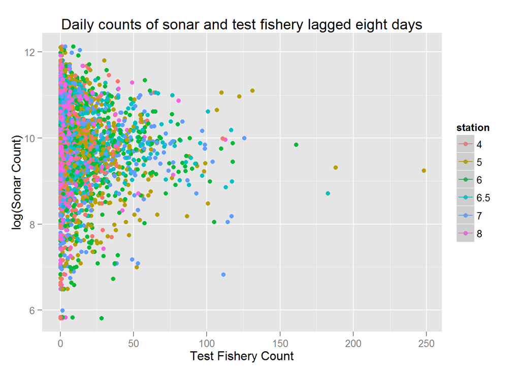

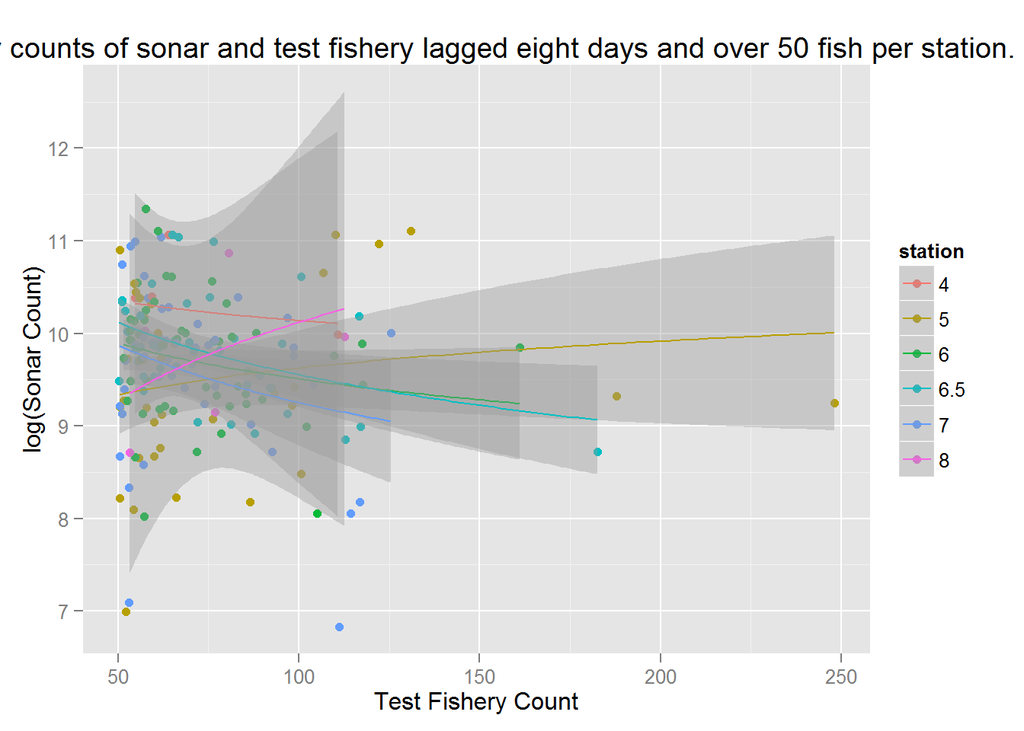

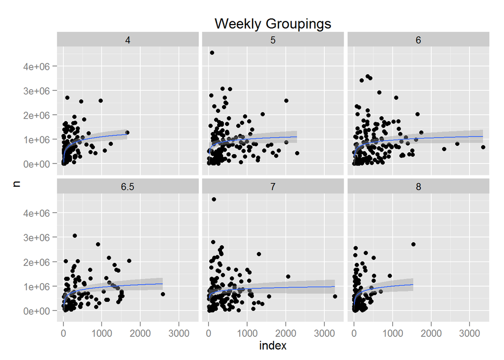

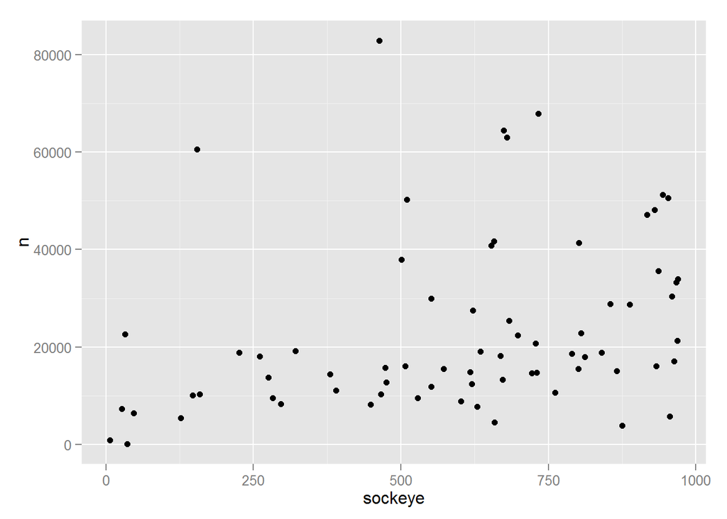